# MainQuartoDoc

Author

Regan Hallead, Emily Hoeft, Will Kapner, Brian Legal

## Background:

Happiness in nations is measured as the average answer when asking people how much they enjoy their life on a scale from zero to ten (or similar). It has been found that the largest contributor of happiness is genetics. Circumstances and actions that people choose to take are also large contributors of happiness (Zidanšek, 2007). Environmental quality greatly impacts human psychology and happiness. New research has determined that extreme climate events and natural hazards, which are becoming more and more common with climate change, may be very important determinants of human happiness. Environmental degradation poses a risk to human physical and mental health. Carbon dioxide emissions are a major factor in environmental degradation (Apergis and Majeed, 2021). Because environmental health may be an increasingly important factor in overall happiness, we are choosing to investigate the relationship between carbon dioxide emissions and human happiness score using data from Gapminder.

## Hypotheses:

We think that more consumption of goods will lead people to live a less fulfilled life. In life, things are not the things that truly matter, but people and relationships instead lead us to live happier lives. Therefore, higher $CO_2$ emissions per capita will be associated with a lower happiness score.

## Description of Data:

Our data is from two data sets from Gapminder. The first data set is the Happiness Score of 163 countries from 2005 to 2022. Each data cell includes data from a sample of people who were asked to rate their life on a scale from 0-10 with 0 being the worst possible life and 10 being the best possible life. Gapminder then converted this data to a scale from 0-100 for easier analysis.

The second set we used is the Consumption $CO_2$ per Capita from fossil fuel consumption, cement production, and gas flaring. Each data cell includes values measured in metric tons per person, throughout 119 countries and from the years 1990 to 2017. The fact that the values are per person is very helpful because we can compare happiness scores to metric tons per person of $CO_2$ emissions easily.

## Data Cleaning Methods:

The data from gapminder was recorded in a CSV file, with the years as the columns and the countries as the rows. We wanted to join the data together in one table so that we could use it for further analysis down the line. In order to join the data, we had to pivot the data as a pivot longer so that the years are put next to the countries for each entry. After doing that, we were able to successfully join the data together. Our current data has some years that don’t overlap with each other, since the happiness scores span from 2005 to 2022, while emissions data was collected between 1990 and 2017. We decided to keep the NA’s in the join for the data that doesn’t have a year associated with the other data. For example, happiness data from 1990 is marked as NA since it was not recorded at the time. We plan on using the years that overlapped within our two data sets for our analysis.

## Happiness and Consumption Over Time:

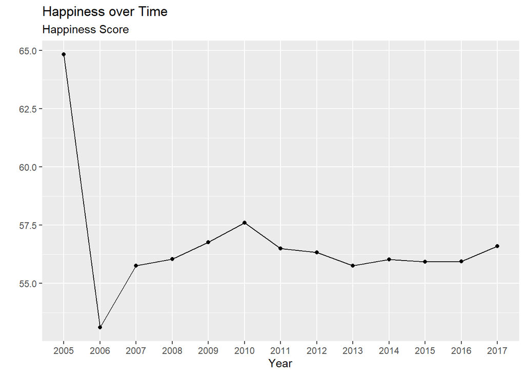

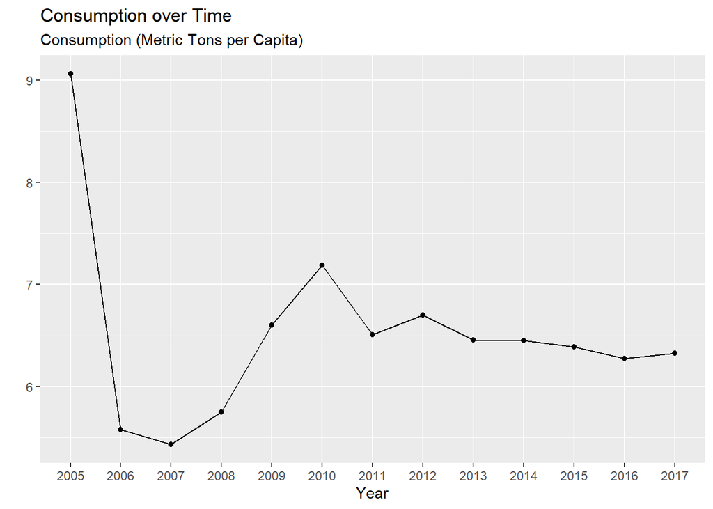

Visually, it looks like happiness and consumption over time have similar trends. In the graphs, they rise and fall at similar years. From this graph, we are predicting that there could be a strong correlation between happiness and consumption over time.

## Linear Regression:

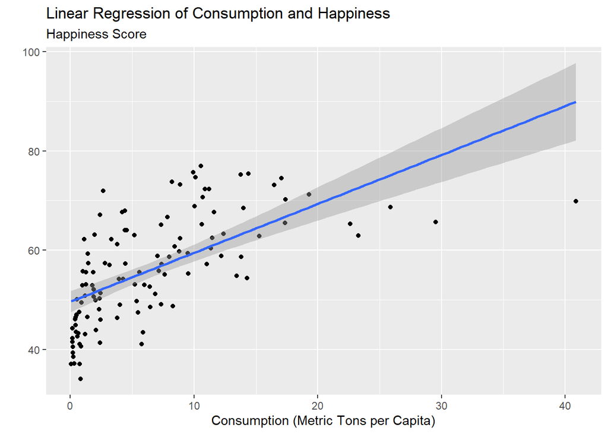

For our linear regression graph, the response variable is Happiness Level and the explanatory variable is the $CO_2$ Consumption per capita. We ended up only using one plot point per country, using the average of the data for each country. When we used linear regression, it produced a line of best fit for our data we graphed. The estimated regression model was found to be:

$$\hat{y} = 49.6096 + 0.9858x$$
In this model, $\hat{y}$ is predicted happiness, and x is $CO_2$ consumption (in metric tons) per capita. For a country with zero emissions per person, the predicted happiness score is 49.6096. For each one metric ton increase in $CO_2$ consumption per capita, the predicted happiness score increases by 0.9858.

In terms of the amount of variation, more of the variation is a product of the residuals than the fitted values. Of the 114.30 total variation from happiness, 68.87 was explained by residuals and 45.43 was explained by fitted values. Therefore, the model is not a great fit for our data.These results may be seen in the table below.

Variance for response variable, residuals and fitted values in model relating happiness to consumption.

| Residual Type | Variance |
| --- | --- |
| Variance in Happiness | 114.30 |
| Variance in Residuals | 68.87 |
| Variance in Fitted Values | 45.43 |